# RSV (ABRYSVO) - Dysstasia

OpenSourcePV

Data Lock Point: Data contains VAERS reports processed as of 2023_12_29 (Year_Month_Day). Flag NEW was defined against reports processed as of 2023_11_24.

# 1 Quantitative Signal status

## 1.1 Disproportionality

The vaccine-event combination “RSV (ABRYSVO) - Dysstasia” was **a signal of disproportionate reporting** with an EB05 value of 2.08.

The threshold for being flagged as a signal of disproportionate reporting is an EB05>=2 meaning that there there is a 95% probability that the reporting of Dysstasia was at least twice post exposure to RSV (ABRYSVO) than post all vaccines [1]. Under the assumption of no causality between RSV (ABRYSVO) and Dysstasia and no bias it would have been expected to observe an EBGM of 1.

It means that the quantified causality criterion of strength of association is **met**.

*It is to be noted that the nature of the spontaneous report does not provide reliable estimates of the strength of association (whatever the choice of the disproportionality method) and that some reporting bias or difference in demographic characteristics might explain the (un)observed disproportion*.

## 1.2 Time-to-onset

The vaccine-event combination “RSV (ABRYSVO) - Dysstasia” was **not a signal of unexpected time-to-onset distribution** with a p-value of the two-sample Kolmogorov-Smirnov test being 0.8663751 and distance between the two empirical cumulative distributions being of 17.2975352%.

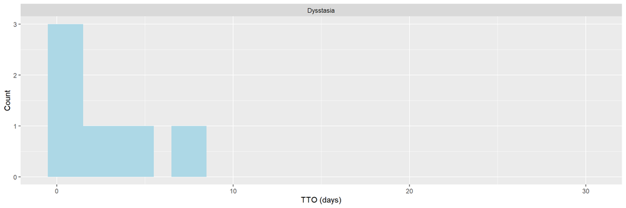

The TTO signal detection method tests if the distribution of Dysstasia post RSV (ABRYSVO) is significantly different from the distribution of Dysstasia post other vaccines using a two-sample Kolmogorov-Smirnov test [2]. The threshold for being flagged as a signal of unexpected time-to-onset distribution is a P-value <0.001 and a distance between the two empirical distributions larger than 20%. Under the assumption of no causality and no bias, it would have been expected that the time-to-onset distribution for “Dysstasia” would have been the same post RSV (ABRYSVO) than post other vaccines.

It means that the quantified causality criterion of temporality is **not met**.

*It is to be noted that the nature of the spontaneous report does not provide reliable estimates of the temporal relationship between the exposure and the occurrence of the events as there is the reporting bias over time: the latter the event occurs after exposure, the less chance it has to be reported. Other biases could distort the reported time-to-onset distribution (media attention, etc.)*

## 1.3 Overall

Based on the screening of the Empirical Bayes Geometric Mean (EBGM) and the screening of the time-to-onset distribution,the vaccine-event combination “RSV (ABRYSVO) - Dysstasia” is **considered as quantitative signal**.

# 2 Signal History

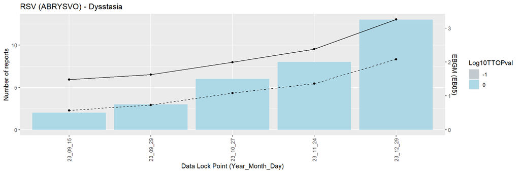

# 3 Case series

## 3.1 Seriousness

A total of 13 reports of Dysstasia were received post exposure to RSV (ABRYSVO). Among them:

- 0 (0.0 %) were fatal cases.
- 1 (7.7 %) were life threatening cases.
- 4 (30.8 %) were hospitalized cases.
- 0 (0.0 %) were emergency room cases.
- 2 (15.4 %) were cases with disabilies.

5 new cases were received since last data refresh.

## 3.2 Demographic characteristics

13 cases of Dysstasia post RSV (ABRYSVO) were reported in VAERS:

- Among them, there were 10 (76.9%) female cases and 3 (23.1%) male cases while the overall female:male ratio is 63:27%.
- The mean (median) age for patients presenting symptoms of Dysstasia was 75 (76) years while the overall mean (median) age was 70 (72) years.
- The top 5 contributing US states for patients presenting symptoms of Dysstasia were GA ( 23.1 %) , AZ ( 7.7 %) , CA ( 7.7 %) , CT ( 7.7 %) , FL ( 7.7 %) while overall the top 5 of contributing US states are NA ( 12.5 %) , CA ( 5.7 %) , OH ( 5.6 %) , PA ( 4.9 %) , NY ( 4.8 %)

# 4 Listing of the cases

Narratives can be made visible clicking on the ⊕ symbol.

|  | VAERS ID | Sex/Age (Years) | Receipt Date | Seriousness status | List of symptoms | New | SYMPTOM_TEXT |
| --- | --- | --- | --- | --- | --- | --- | --- |
| &oplus; | 2719812 | F/76 | 12/01/2023 | Hospitalized | Activated partial thromboplastin time, Anti factor Xa assay, Antibody test, Antineutrophil cytoplasmic antibody, Antinuclear antibody, Asthenia, Bacterial test, Balance disorder, Blood creatine phosph… | Yes | 10 12 23 Received the Abrysvo Bivalent RSV vaccine from Pfizer HF5018 into left arm at pharmacy No symptoms to report after vaccine 10 13 23 to 10 15 23 Sore left arm No other symptoms to report 10 17… |
| &oplus; | 2720659 | M/86 | 12/04/2023 |  | Dysstasia, Gait disturbance, Muscular weakness | Yes | On the morning of 01 December 2023 Patient woke up and commented he had muscle weakness in his legs had difficulty rising from sitting position and was very unsteady on his feet throughout the day bal… |
| &oplus; | 2724118 | F/77 | 12/14/2023 |  | Back pain, Dysstasia, Nausea, Renal pain | Yes | Patient reports Nausea Kidney Back pain hard to stand Symptoms started the following morning after vaccine administration Patient had also received a prevnar 20 from her doctor the same morning prior … |
| &oplus; | 2724970 | F/73 | 12/18/2023 |  | Arthralgia, Dysstasia, Gait disturbance, Hypoaesthesia, Muscular weakness, Neck pain, Neuralgia, Pain in extremity, Paraesthesia, Sensory loss, Walking aid user | Yes | Initially the day after injections I was unable to stand up I couldnt grasp with my hands to pull myself up Eventually I was able to stand up and walk unsteadily with the use of a cane Severe aches an… |
| &oplus; | 2727933 | F/73 | 12/28/2023 |  | Dysstasia, Muscular weakness, Musculoskeletal disorder | Yes | My legs stopped working my legs just collapse I cannot stand up This is a spontaneous report received from a Consumer or other non HCP from medical information team A 73 year old female patient receiv… |
| &oplus; | 2680704 | F/75 | 09/10/2023 |  | Confusional state, Diarrhoea, Dysstasia, Headache, Myalgia, Pyrexia, Vomiting | No | 200 PM Sudden onset of confusion severe Headache vomiting diarrhea inability toto stand or w c transfer from chair to bed Incontinent Low grade fever 6 days Headache 5 days Muscle Aches 5 days unrelen… |
| &oplus; | 2681276 | F/77 | 09/12/2023 |  | Arthralgia, Condition aggravated, Dysstasia, Myalgia, Pain in extremity | No | In mid afternoon of the day I received the vaccination and for the next 3 to 4 afternoons I experienced joint and muscle aches I had difficulty standing up from a seated position which is abnormal for… |
| &oplus; | 2684666 | M/70 | 09/21/2023 |  | Dizziness, Dysstasia, Hypertension, Mobility decreased, Muscular weakness | No | High blood pressure 177 111 weakness in legs and arms dizziness cant get up from sitting position or laying position if on the floor cant get up from that position Outcome most adverse events ended ab… |
| &oplus; | 2689852 | M/78 | 10/03/2023 | Hospitalized | Asthenia, Blood culture negative, Dysstasia, Influenza like illness, Laboratory test, Neurological symptom | No | Pt arrives via EMS from home due to weakness and not being able to stand Pt states that he received the COVID and RSV vaccines yesterday Pt stated feeling fine yesterday prior to vaccines Patient was … |
| &oplus; | 2692496 | F/77 | 10/08/2023 |  | Dysstasia, Fear, Gait inability, Heart rate irregular, Influenza like illness, Injection site paraesthesia, Pain, Palpitations, Paraesthesia | No | shortly after receiving the vaccines I got a tingly sensation starting from my left arm up into my shoulders and it traveled all the way down my spine where it caused me to not be able to stand or wal… |

[output cut: 3 more lines]

# 5 Disclaimer

This analysis is exploratory only and authors cannot be held responsible for any decision made using these data. It is important to distinguish quantitative signals such as disproportionate reporting, unexpected time-to-onset patterns or cluster from safety signals. Only a qualitative review using multiple data source (literature, clinical trials, etc.) and multiple causality criteria assessment could qualify quantitative signals into safety signals.

# 6 References

[1] Dumouchel W. Bayesian data mining in large frequency tables, with an application to the FDA spontaneous reporting system. Am Stat 1999; 53: 177–190.

[2] Van Holle L et al, Using time‐to‐onset for detecting safety signals in spontaneous reports of adverse events following immunization: a proof-of-concept study. Pharmacoepidemiology and Drug Safety 21 (6), 603-610.